# This project will be divided into 3 Phases

- Phase one (Cleaning Data, EDA , Feature engineering, Preprocessing , Splitting Data, Oversampling [if needed])
- Phase two (Model Selection & Hyperparamater tuning)
- Phase three (Evaluation & Final insights)

# Phase one

'?' Were explicitly identified as NA values, since pandas initially registered it as a categorical value.

```python
import pandas as pd
df = pd.read_csv("C:/Users/Farid/Desktop/Uni/Machine Learning/Final Project/diabetic_data.csv", na_values='?')
```

Initial Overview, To see data shape and structure

```python
print("Initial shape:", df.shape)
print("Data types:\n", df.dtypes)
print("Missing values:\n", df.isnull().sum())
```

```
Initial shape: (101766, 50)
Data types:
 encounter_id                 int64
patient_nbr                  int64
race                        object
gender                      object
age                         object
weight                      object
admission_type_id            int64
discharge_disposition_id     int64
admission_source_id          int64
time_in_hospital             int64
payer_code                  object
medical_specialty           object
num_lab_procedures           int64
num_procedures               int64
num_medications              int64
number_outpatient            int64
number_emergency             int64
number_inpatient             int64
diag_1                      object
diag_2                      object
diag_3                      object
number_diagnoses             int64
max_glu_serum               object
A1Cresult                   object
metformin                   object
repaglinide                 object
nateglinide                 object
chlorpropamide              object
glimepiride                 object
acetohexamide               object
glipizide                   object
glyburide                   object
tolbutamide                 object
pioglitazone                object
rosiglitazone               object
acarbose                    object
miglitol                    object
troglitazone                object
```

[output cut: 50 more lines]

```
miglitol                        0
troglitazone                    0
tolazamide                      0
examide                         0
citoglipton                     0
insulin                         0
glyburide-metformin             0
glipizide-metformin             0
glimepiride-pioglitazone        0
metformin-rosiglitazone         0
metformin-pioglitazone          0
change                          0
diabetesMed                     0
readmitted                      0
dtype: int64
```

Section One - Initial Cleaning [Dropping Empty Columns, Columns with no unique values, low variance columns, and correctly encoding some of the values in the drug columns. ]

Dropping Irrelevant Columns: Targeted columns with a huge numbe of missing values or irrelevant to the study (e.g. encounter ID is just an identifier that would not contibute, kept patient identifier as as the same patient could come in for a vist multiple times, keeping it would be essential for contributing to the model)

```python
df.drop(columns=['encounter_id', 'weight', 'payer_code', 'medical_specialty'], inplace=True)
```

After inspecting the paper which this dataset had come from, I decided to drop the columns with either a very high number of missing values, or no unique values (meaning that it would no contribute to the machine learning model at all). Note that I did not drop the patient number column, as the same patient could come in for multiple encounters. Keeping this data is valuable to keep the model unbiased.

Drop Columns with Single Unique Value

```python
unique_counts = df.nunique()
cols_to_drop = unique_counts[unique_counts == 1].index.tolist()
print("Dropping columns:", cols_to_drop)
df.drop(columns=cols_to_drop, inplace=True)
```

```
Dropping columns: ['examide', 'citoglipton']
```

Other columns seem to have unique values but they are extremely sparse, meaning that they would contribtute to added noise and increased model dimensionality. The best practice here would be to define a threshold, such as a 99.5% of rows sharing the same value, and drop those too.

```python
low_variance_cols = [
    col for col in df.columns
    if df[col].value_counts(normalize=True, dropna=False).values[0] > 0.995
]
print("Dropping low-variance columns:", low_variance_cols)
df.drop(columns=low_variance_cols, inplace=True)
```

```
Dropping low-variance columns: ['chlorpropamide', 'acetohexamide', 'tolbutamide', 'acarbose', 'miglitol', 'troglitazone', 'tolazamide', 'glipizide-metformin', 'glimepiride-pioglitazone', 'metformin-rosiglitazone', 'metformin-pioglitazone']
```

```python
df['max_glu_serum'] = df['max_glu_serum'].replace('None', 'NoTest')
df['A1Cresult'] = df['A1Cresult'].replace('None', 'NoTest')
```

For the age feature, I decided that the best option would be to convert the age ranges to its respective midpoint integer, on the csv file they are written as ranges (e.g. [0-10)), so encoding it as 5 would make it easier to deal with.

```python
age_mapping = {
    '[0-10)': 5, '[10-20)': 15, '[20-30)': 25, '[30-40)': 35,
    '[40-50)': 45, '[50-60)': 55, '[60-70)': 65,
    '[70-80)': 75, '[80-90)': 85, '[90-100)': 95
}
df['age'] = df['age'].map(age_mapping)
```

Section Two - EDA

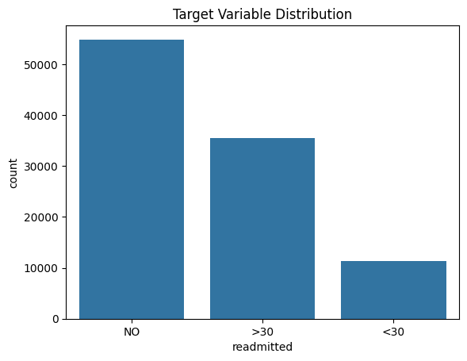

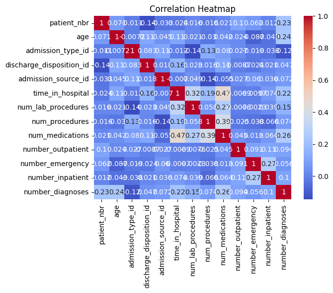

```
Class distribution:
 readmitted
NO     0.539119
>30    0.349282
<30    0.111599
Name: proportion, dtype: float64
Value counts for race:
 race
Caucasian          76099
AfricanAmerican    19210
Hispanic            2037
Other               1506
Asian                641
Name: count, dtype: int64
Value counts for gender:
 gender
Female             54708
Male               47055
Unknown/Invalid        3
Name: count, dtype: int64
```

```python
import seaborn as sns
import matplotlib.pyplot as plt

#target distribution
sns.countplot(x='readmitted', data=df)
plt.title("Target Variable Distribution")
plt.show()

#correlation with numeric columns (after age mapping)
numeric_cols = df.select_dtypes(include=['int64', 'float64']).columns
sns.heatmap(df[numeric_cols].corr(), annot=True, cmap='coolwarm')
plt.title("Correlation Heatmap")
plt.show()

#class balance
print("Class distribution:\n", df['readmitted'].value_counts(normalize=True))

#inspecting categorical values
print("Value counts for race:\n", df['race'].value_counts())
print("Value counts for gender:\n", df['gender'].value_counts())
```

Removed rows with "Unknown/Invalid" in gender to ensure clean categorical data.

```python
#drop rows with invalid gender values
df = df[df['gender'] != 'Unknown/Invalid']
```

The Diagnosis Columns are extremely crucial with diminishing returns (e.g. Diag1 is more important than 2 and 3 is more important than 3.) We could drop diagnosis 3 since it has the most missing values, but it is still only 1% missing values so it's fine to replace the NA values with Unknown.

```python
df['diag_1'] = df['diag_1'].fillna('Unknown')
df['diag_2'] = df['diag_2'].fillna('Unknown')
df['diag_3'] = df['diag_3'].fillna('Unknown')
```

Define Features and Target and Train-Test Split

```python
from sklearn.model_selection import train_test_split
#Binary target conversion for the target column.
y = df['readmitted'].apply(lambda x: 1 if x == '<30' else 0)
X = df.drop('readmitted', axis=1)

#Train/test split
X_train, X_test, y_train, y_test = train_test_split(
    X, y, test_size=0.2, stratify=y, random_state=42
)
```

After splitting the data into X_train and X_test, so now we can build a preprocessing pipeline that does 3 main things,

```
1. Imputes missing values

2. Scales numeric features

3. One-hot encodes categorical features

    This will ensure our model receives clean, properly transformed data.
```

Additional information since the column transformer and the sklearn.pipeline imports since they were not mentioned at any point during the course:

1. from sklearn.compose import columntransformer

Lets you apply different preprocessing to different columns like numbers get scaled and text gets encoded all in 1 step

2. from sklearn.pipeline import pipeline

Makes a chain of steps like preprocess then model so u can fit/predict in 1 go

```python
from sklearn.compose import ColumnTransformer
from sklearn.pipeline import Pipeline
from sklearn.impute import SimpleImputer
from sklearn.preprocessing import OneHotEncoder, StandardScaler

#identify column types
numeric_features = X_train.select_dtypes(include=['int64', 'float64']).columns.tolist()
categorical_features = X_train.select_dtypes(include=['object']).columns.tolist()

#numeric pipeline
numeric_transformer = Pipeline(steps=[
    ('imputer', SimpleImputer(strategy='median')),
    ('scaler', StandardScaler())
])

#categorical pipeline
categorical_transformer = Pipeline(steps=[
    ('imputer', SimpleImputer(strategy='constant', fill_value='missing')),
    ('onehot', OneHotEncoder(handle_unknown='ignore'))
])

#combined preprocessor
preprocessor = ColumnTransformer(transformers=[
    ('num', numeric_transformer, numeric_features),
    ('cat', categorical_transformer, categorical_features)
])
```

```python
#Fit-transform training data using preprocessor
X_train_processed = preprocessor.fit_transform(X_train)
```

- SMOTE was applied to oversample the minority <30 readmission class after splitting the data. This helps the model learn patterns for rare readmissions without leaking test data.

```python
X_test_processed = preprocessor.transform(X_test)
#Apply SMOTE
from imblearn.over_sampling import SMOTE
smote = SMOTE(random_state=42)
X_train_resampled, y_train_resampled = smote.fit_resample(X_train_processed, y_train)
```

```python
print("Current shape: ", df.shape)
print("Data types:\n", df.dtypes)
print("Missing values:\n", df.isnull().sum())
```

```
Current shape:  (101763, 33)
Data types:
 patient_nbr                  int64
race                        object
gender                      object
age                          int64
admission_type_id            int64
discharge_disposition_id     int64
admission_source_id          int64
time_in_hospital             int64
num_lab_procedures           int64
num_procedures               int64
num_medications              int64
number_outpatient            int64
number_emergency             int64
number_inpatient             int64
diag_1                      object
diag_2                      object
diag_3                      object
number_diagnoses             int64
max_glu_serum               object
A1Cresult                   object
metformin                   object
repaglinide                 object
nateglinide                 object
glimepiride                 object
glipizide                   object
glyburide                   object
pioglitazone                object
rosiglitazone               object
insulin                     object
glyburide-metformin         object
change                      object
diabetesMed                 object
readmitted                  object
dtype: object
Missing values:
 patient_nbr                     0
race                         2271
gender                          0
```

[output cut: 16 more lines]

```
A1Cresult                   84745
metformin                       0
repaglinide                     0
nateglinide                     0
glimepiride                     0
glipizide                       0
glyburide                       0
pioglitazone                    0
rosiglitazone                   0
insulin                         0
glyburide-metformin             0
change                          0
diabetesMed                     0
readmitted                      0
dtype: int64
```

Mode imputation for the 2% missing values on the race column:

```python
df['race'] = df['race'].fillna(df['race'].mode()[0])
```

To Handle max_glu_serum and A1Cresult, while Both have too much missing data to impute confidently.

Converted the values to binary “test taken or not”

[output not shown]

```python
df['max_glu_serum'] = df['max_glu_serum'].replace('None', 'NoTest')
df['A1Cresult'] = df['A1Cresult'].replace('None', 'NoTest')

df['max_glu_serum'] = df['max_glu_serum'].apply(lambda x: 0 if x == 'NoTest' else 1)
df['A1Cresult'] = df['A1Cresult'].apply(lambda x: 0 if x == 'NoTest' else 1)
```

# Phase two and three

First Model to test: Random Forest Hyperparamaters to tune:

- n_estimators: Number of trees.
- max_depth: Max depth of trees.
- min_samples_split: Minimum samples required to split.

To efficiently select the best hyperparameters, the following steps will be taken:

```python
from sklearn.ensemble import RandomForestClassifier
from sklearn.metrics import accuracy_score, precision_score, recall_score, f1_score
import matplotlib.pyplot as plt
import itertools
import pandas as pd

# Define hyperparameter grid
n_estimators = [50, 100, 150]
max_depth = [5, 10, None]
min_samples_split = [2, 5]

# Create a list of all combinations
param_combinations = list(itertools.product(n_estimators, max_depth, min_samples_split))

# Store results
results = []

for n, d, s in param_combinations:
    clf = RandomForestClassifier(n_estimators=n, max_depth=d, min_samples_split=s, random_state=42)
    clf.fit(X_train_processed, y_train)

    y_pred = clf.predict(X_test_processed)

    acc = accuracy_score(y_test, y_pred)
    prec = precision_score(y_test, y_pred, average='weighted', zero_division=0)
    rec = recall_score(y_test, y_pred, average='weighted', zero_division=0)
    f1 = f1_score(y_test, y_pred, average='weighted', zero_division=0)

    results.append({
        'n_estimators': n,
        'max_depth': d if d is not None else "None",
        'min_samples_split': s,
        'accuracy': acc,
        'precision': prec,
        'recall': rec,
        'f1_score': f1
    })

# Convert to DataFrame
results_df = pd.DataFrame(results)

# Sort results by recall descending
results_df_sorted = results_df.sort_values(by='recall', ascending=False)
print(results_df_sorted.head())
```

```
    n_estimators max_depth  min_samples_split  accuracy  precision    recall  \
4             50      None                  2  0.888911   0.873532  0.888911
5             50      None                  5  0.888763   0.868493  0.888763
16           150      None                  2  0.888763   0.875494  0.888763
10           100      None                  2  0.888763   0.871522  0.888763
17           150      None                  5  0.888665   0.885157  0.888665

    f1_score
4   0.837591
5   0.837235
16  0.837047
10  0.837141
17  0.836619
```

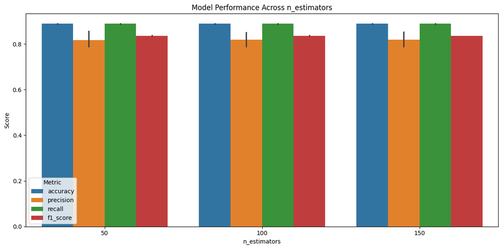

```python
import seaborn as sns

# Reshape data for plotting
results_df_long = results_df.melt(id_vars=['n_estimators', 'max_depth', 'min_samples_split'],
                                  value_vars=['accuracy', 'precision', 'recall', 'f1_score'],
                                  var_name='metric', value_name='score')

# Plot
plt.figure(figsize=(12, 6))
sns.barplot(x='n_estimators', y='score', hue='metric', data=results_df_long)
plt.title("Model Performance Across n_estimators")
plt.ylabel("Score")
plt.xlabel("n_estimators")
plt.legend(title="Metric")
plt.tight_layout()
plt.show()
```

```python
best_model_row = results_df_sorted.iloc[0]
print("Best model hyperparameters:")
print(best_model_row[['n_estimators', 'max_depth', 'min_samples_split']])
print("\nPerformance Metrics:")
print(best_model_row[['accuracy', 'precision', 'recall', 'f1_score']])
```

```
Best model hyperparameters:
n_estimators           50
max_depth            None
min_samples_split       2
Name: 4, dtype: object

Performance Metrics:
accuracy     0.888911
precision    0.873532
recall       0.888911
f1_score     0.837591
Name: 4, dtype: object
```

```python
from xgboost import XGBClassifier
from sklearn.metrics import accuracy_score, precision_score, recall_score, f1_score
import itertools
import pandas as pd

# Define hyperparameter grid
n_estimators = [50, 100, 150]
max_depth = [3, 6, 10]
learning_rate = [0.01, 0.1, 0.2]

# Create list of all combinations
param_combinations = list(itertools.product(n_estimators, max_depth, learning_rate))

# Store results
xgb_results = []

for n, d, lr in param_combinations:
    clf = XGBClassifier(
        n_estimators=n,
        max_depth=d,
        learning_rate=lr,
        random_state=42,
        verbosity=0  # disables training logs
    )

    clf.fit(X_train_processed, y_train)
    y_pred = clf.predict(X_test_processed)

    acc = accuracy_score(y_test, y_pred)
    prec = precision_score(y_test, y_pred, average='weighted', zero_division=0)
    rec = recall_score(y_test, y_pred, average='weighted', zero_division=0)
    f1 = f1_score(y_test, y_pred, average='weighted', zero_division=0)

    xgb_results.append({
        'n_estimators': n,
        'max_depth': d,
        'learning_rate': lr,
        'accuracy': acc,
        'precision': prec,
        'recall': rec,
        'f1_score': f1
    })

# Convert to DataFrame
xgb_results_df = pd.DataFrame(xgb_results)

# Sort by recall
xgb_results_df_sorted = xgb_results_df.sort_values(by='recall', ascending=False)
print(xgb_results_df_sorted.head())
```

```
    n_estimators  max_depth  learning_rate  accuracy  precision    recall  \
16           100         10           0.10  0.889255   0.855262  0.889255
22           150          6           0.10  0.889206   0.857712  0.889206
7             50         10           0.10  0.889206   0.855421  0.889206
13           100          6           0.10  0.889156   0.857842  0.889156
24           150         10           0.01  0.889156   0.864769  0.889156

    f1_score
16  0.842676
22  0.840831
7   0.842051
13  0.840451
24  0.839102
```

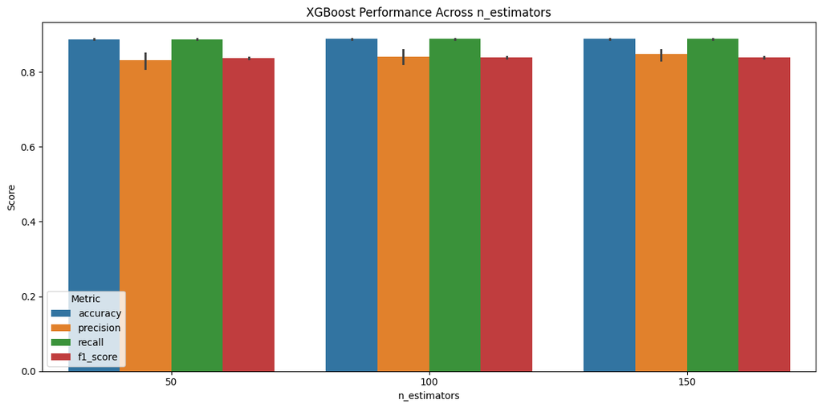

```python
import seaborn as sns
import matplotlib.pyplot as plt

# Reshape for plotting
xgb_results_long = xgb_results_df.melt(
    id_vars=['n_estimators', 'max_depth', 'learning_rate'],
    value_vars=['accuracy', 'precision', 'recall', 'f1_score'],
    var_name='metric',
    value_name='score'
)

# Plot
plt.figure(figsize=(12, 6))
sns.barplot(x='n_estimators', y='score', hue='metric', data=xgb_results_long)
plt.title("XGBoost Performance Across n_estimators")
plt.ylabel("Score")
plt.xlabel("n_estimators")
plt.legend(title="Metric")
plt.tight_layout()
plt.show()
```

```python
best_xgb_row = xgb_results_df_sorted.iloc[0]
print("Best XGBoost hyperparameters:")
print(best_xgb_row[['n_estimators', 'max_depth', 'learning_rate']])
print("\nPerformance Metrics:")
print(best_xgb_row[['accuracy', 'precision', 'recall', 'f1_score']])
```

```
Best XGBoost hyperparameters:
n_estimators     100.0
max_depth         10.0
learning_rate      0.1
Name: 16, dtype: float64

Performance Metrics:
accuracy     0.889255
precision    0.855262
recall       0.889255
f1_score     0.842676
Name: 16, dtype: float64
```

```python
from sklearn.linear_model import LogisticRegression
from sklearn.pipeline import Pipeline
from sklearn.metrics import classification_report, confusion_matrix

# Define logistic regression pipeline
log_reg_pipeline = Pipeline(steps=[
    ('preprocessor', preprocessor),
    ('classifier', LogisticRegression(max_iter=1000, random_state=42))
])

# Train the pipeline
log_reg_pipeline.fit(X_train, y_train)

# Predict on test data
y_pred_log_reg = log_reg_pipeline.predict(X_test)

# Evaluation
print("Logistic Regression - Classification Report:\n", classification_report(y_test, y_pred_log_reg))
print("Logistic Regression - Confusion Matrix:\n", confusion_matrix(y_test, y_pred_log_reg))

# Define logistic regression pipeline
log_reg_pipeline = Pipeline(steps=[
    ('preprocessor', preprocessor),
    ('classifier', LogisticRegression(max_iter=1000, random_state=42))
])

# Train the pipeline
log_reg_pipeline.fit(X_train, y_train)

# Predict on test data
y_pred_log_reg = log_reg_pipeline.predict(X_test)

# Evaluation
print("Logistic Regression - Classification Report:\n", classification_report(y_test, y_pred_log_reg))
print("Logistic Regression - Confusion Matrix:\n", confusion_matrix(y_test, y_pred_log_reg))
```

```
Logistic Regression - Classification Report:
               precision    recall  f1-score   support

           0       0.89      1.00      0.94     18082
           1       0.51      0.02      0.04      2271

    accuracy                           0.89     20353
   macro avg       0.70      0.51      0.49     20353
weighted avg       0.85      0.89      0.84     20353

Logistic Regression - Confusion Matrix:
 [[18042    40]
 [ 2229    42]]
Logistic Regression - Classification Report:
               precision    recall  f1-score   support

           0       0.89      1.00      0.94     18082
           1       0.51      0.02      0.04      2271

    accuracy                           0.89     20353
   macro avg       0.70      0.51      0.49     20353
weighted avg       0.85      0.89      0.84     20353

Logistic Regression - Confusion Matrix:
 [[18042    40]
 [ 2229    42]]
```

```python
#Get best performing model from each algorithm
best_rf = results_df_sorted.iloc[0]
best_xgb = xgb_results_df_sorted.iloc[0]

#Extract metrics for comparison
comparison_data = {
    'Model': ['Random Forest', 'XGBoost'],
    'accuracy': [best_rf['accuracy'], best_xgb['accuracy']],
    'precision': [best_rf['precision'], best_xgb['precision']],
    'recall': [best_rf['recall'], best_xgb['recall']],
    'f1_score': [best_rf['f1_score'], best_xgb['f1_score']]
}

#Add Logistic Regression
try:
    log_reg_accuracy = accuracy_score(y_test, y_pred_log_reg)
    log_reg_precision = precision_score(y_test, y_pred_log_reg, average='weighted', zero_division=0)
    log_reg_recall = recall_score(y_test, y_pred_log_reg, average='weighted', zero_division=0)
    log_reg_f1 = f1_score(y_test, y_pred_log_reg, average='weighted', zero_division=0)

    comparison_data['Model'].append('Logistic Regression')
    comparison_data['accuracy'].append(log_reg_accuracy)
    comparison_data['precision'].append(log_reg_precision)
    comparison_data['recall'].append(log_reg_recall)
    comparison_data['f1_score'].append(log_reg_f1)
except NameError:
    print("Logistic Regression results not found — skipping from comparison")

#comparison DataFrame
comparison_df = pd.DataFrame(comparison_data)

#sort by recall to find the top model
comparison_df_sorted = comparison_df.sort_values(by='recall', ascending=False)
print("\nTop Evaluating Model:\n")
print(comparison_df_sorted.head(1))

#show full comparison table
print("\nFull Model Comparison:")
print(comparison_df_sorted.reset_index(drop=True))
```

```
Top Evaluating Model:

     Model  accuracy  precision    recall  f1_score
1  XGBoost  0.889255   0.855262  0.889255  0.842676

Full Model Comparison:
                 Model  accuracy  precision    recall  f1_score
0              XGBoost  0.889255   0.855262  0.889255  0.842676
1        Random Forest  0.888911   0.873532  0.888911  0.837591
2  Logistic Regression  0.888518   0.847880  0.888518  0.839843
```

```python
from xgboost import XGBClassifier

# Retrain best XGBoost model on resampled training data
final_model = XGBClassifier(
    n_estimators=100,
    max_depth=10,
    learning_rate=0.1,
    random_state=42
)

final_model.fit(X_train_resampled, y_train_resampled)
```

```
XGBClassifier(base_score=None, booster=None, callbacks=None,
              colsample_bylevel=None, colsample_bynode=None,
              colsample_bytree=None, device=None, early_stopping_rounds=None,
              enable_categorical=False, eval_metric=None, feature_types=None,
              feature_weights=None, gamma=None, grow_policy=None,
              importance_type=None, interaction_constraints=None,
              learning_rate=0.1, max_bin=None, max_cat_threshold=None,
              max_cat_to_onehot=None, max_delta_step=None, max_depth=10,
              max_leaves=None, min_child_weight=None, missing=nan,
              monotone_constraints=None, multi_strategy=None, n_estimators=100,
              n_jobs=None, num_parallel_tree=None, ...)
```

```python
#recreate and retrain the best model
from xgboost import XGBClassifier

best_xgb = XGBClassifier(
    n_estimators=int(best_xgb_row['n_estimators']),
    max_depth=int(best_xgb_row['max_depth']),
    learning_rate=float(best_xgb_row['learning_rate']),
    random_state=42,
    verbosity=0
)

best_xgb.fit(X_train_processed, y_train)

#save the model to disk
best_xgb.save_model("model.json")
```